# Predicting quality of dumbbell biceps curl

Kantapon Dissaneewate

10/9/2564

## Getting start

Get started by loading required packages. I used tidyverse to clean the data and caret package to develop machine learning algorithm, then load test and train data set for analysis. Then set seed to 1 for reproducibility.

```r
library(tidyverse)
library(caret)
pmltrain <- read.csv(file = 'pml-training.csv')
pmltest <- read.csv(file = 'pml-testing.csv')
set.seed(1)
```

After initial exploration of the data sets, I found that multiple variable were missing from both test and train set. I need to exclude those variable missing from the test data set as to not waste valuable processor resources.  
I selected columns that were not in ‘todel’ then looked at the remaining variable and found that ‘X’, ‘user_name’, ‘raw_timestamp_part_1’, ‘cvtd_timestamp’, ‘new_window’ and ‘num_window’ are most likely irrelevant. Because I couldn’t find a code book for the data set, I was skeptical to remove raw_timestamp_part_2 because I think that it is how much time passed since the first time stamp, which may indicate certain activities. Then I look at ‘classe’ variable, our outcomes and find it to be character type, so I mutate it into factor with 5 level: A B C D E  
A being perfect form of dumbbell biceps curl and E being poorest form.

```r
str(pmltest)
```

```
## 'data.frame':    20 obs. of  160 variables:
##  $ X                       : int  1 2 3 4 5 6 7 8 9 10 ...
##  $ user_name               : chr  "pedro" "jeremy" "jeremy" "adelmo" ...
##  $ raw_timestamp_part_1    : int  1323095002 1322673067 1322673075 1322832789 1322489635 1322673149 1322673128 1322673076 1323084240 1322837822 ...
##  $ raw_timestamp_part_2    : int  868349 778725 342967 560311 814776 510661 766645 54671 916313 384285 ...
##  $ cvtd_timestamp          : chr  "05/12/2011 14:23" "30/11/2011 17:11" "30/11/2011 17:11" "02/12/2011 13:33" ...
##  $ new_window              : chr  "no" "no" "no" "no" ...
##  $ num_window              : int  74 431 439 194 235 504 485 440 323 664 ...
##  $ roll_belt               : num  123 1.02 0.87 125 1.35 -5.92 1.2 0.43 0.93 114 ...
##  $ pitch_belt              : num  27 4.87 1.82 -41.6 3.33 1.59 4.44 4.15 6.72 22.4 ...
##  $ yaw_belt                : num  -4.75 -88.9 -88.5 162 -88.6 -87.7 -87.3 -88.5 -93.7 -13.1 ...
##  $ total_accel_belt        : int  20 4 5 17 3 4 4 4 4 18 ...
##  $ kurtosis_roll_belt      : logi  NA NA NA NA NA NA ...
##  $ kurtosis_picth_belt     : logi  NA NA NA NA NA NA ...
##  $ kurtosis_yaw_belt       : logi  NA NA NA NA NA NA ...
```

[output cut: 86 more lines]

```r
todel <- names(which(colSums(is.na(pmltest)) > 0))
class(pmltrain$classe)
```

```
## [1] "character"
```

```r
pmltrain <- pmltrain %>%
  select(-c(todel,'X','user_name','raw_timestamp_part_1','cvtd_timestamp',
            'new_window','num_window')) %>%
  mutate(classe = factor(classe))
```

```
## Note: Using an external vector in selections is ambiguous.
## i Use `all_of(todel)` instead of `todel` to silence this message.
## i See <https://tidyselect.r-lib.org/reference/faq-external-vector.html>.
```

I am now left with 53 predictors and 1 outcome variable.

## Machine learning and Cross validation

I plan to use Random forest method with 5-fold cross validation, even though Random forest kind of have a built in cross validation by bootstrap already. It doesn’t hurt to do cross validation, which is easy to do using caret package.

```r
control <- trainControl(method = "cv", number = 5)
RF <- train(classe~., method = 'rf', data = pmltrain, trControl = control)
```

```r
RF
```

```
## Random Forest
##
## 19622 samples
##    53 predictor
##     5 classes: 'A', 'B', 'C', 'D', 'E'
##
## No pre-processing
## Resampling: Cross-Validated (5 fold)
## Summary of sample sizes: 15697, 15699, 15698, 15697, 15697
## Resampling results across tuning parameters:
##
##   mtry  Accuracy   Kappa
##    2    0.9941390  0.9925854
##   27    0.9941903  0.9926507
##   53    0.9888392  0.9858804
##
## Accuracy was used to select the optimal model using the largest value.
## The final value used for the model was mtry = 27.
```

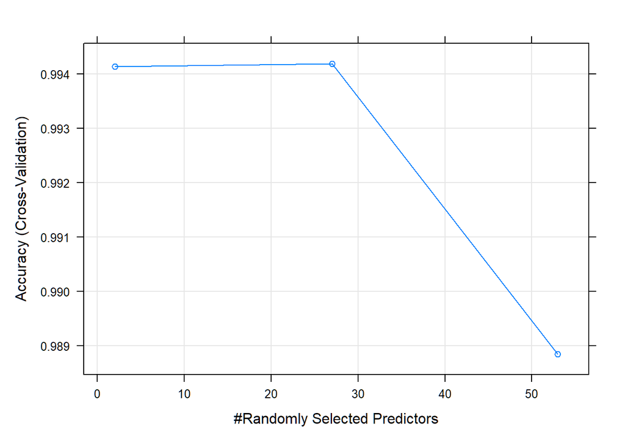

```r
plot(RF)
```

Then I evaluate the results for training set and found that the model correctly predict all 19622 observations

```r
testtrain <- predict(RF)
results <- data.frame(indicator = pmltrain$classe, predict = testtrain)
table(results$indicator, results$predict)
```

```
##
##        A    B    C    D    E
##   A 5580    0    0    0    0
##   B    0 3797    0    0    0
##   C    0    0 3422    0    0
##   D    0    0    0 3216    0
##   E    0    0    0    0 3607
```

With such a promising results, I am now hopeful that this model will do well in the test set. I used the model to predict test set and put those results in the quiz for test set and got 20/20 perfect score.

```r
testresult <- predict(RF, newdata = pmltest)
print(testresult)
```

```
##  [1] B A B A A E D B A A B C B A E E A B B B
## Levels: A B C D E
```